# day 3: text analysis

jean prado

12 jun. 2021

os exercícios aqui são baseados no [dia 3 do SICSS](https://github.com/compsocialscience/summer-institute/tree/master/2020/materials/day3-text-analysis). **nota:** nessa análise estou usando a versão nova do pipe (`|>`, que na [fonte do código](https://github.com/tonsky/FiraCode) é mostrada como `|>`) no lugar da versão do `magrittr`, a `%>%`. para mais informações, veja [esse post da Bea](https://beatrizmilz.com/blog/2021-05-18-experimentando-o-r-410/).

## puxa dados do Twitter

o que será que estão falando da Amazônia? puxei 10 mil tweets com a palavra **amazônia** em português de **4 a 12 de junho**.

```r
#do not run - tweets already saved at data-raw/tweets-amazonia.rds
# raw <- rtweet::search_tweets(q = "amazônia lang:pt", n = 18000,
#                       include_rts = FALSE, type = "mixed")
# raw |> saveRDS(file = "../data-raw/tweets-amazonia.rds")

raw <- readRDS(file = "../data-raw/tweets-amazonia.rds")
```

## pré-processamento

para mais informações, veja o [código anotado](https://sicss.io/2020/materials/day3-text-analysis/basic-text-analysis/rmarkdown/Basic_Text_Analysis_in_R.html) da aula de pré-processamento.

antes até de começar o pré-processamento, vou remover os links do texto dos tweets. [da primeira vez](https://github.com/jeanprado/sicss-notes/commit/fe9f5ba50b954de0c1b7552b49187637f4a58a11) não fiz isso e em algumas partes da análise apareceu uma sequência de texto aleatório, como `dj1398d928`, que era o final das URLs. mais fácil remover esse tipo de coisa antes de tokenizar o texto (quebrar em palavras únicas).

para remover as URLs do texto, usei uma [regex](https://pt.wikipedia.org/wiki/Express%C3%A3o_regular) que adaptei [dessa thread](https://stackoverflow.com/questions/1400431/regular-expression-match-any-word-until-first-space) no stack overflow. (ninguém é de ferro, né?)

```r
tweets <- raw |>
  dplyr::mutate(text = stringr::str_remove_all(text, "https([^\\s]+)"))

tt <- tweets |> dplyr::select(created_at, text) |>
  tidytext::unnest_tokens("word", text)
```

### remove as stopwords

tirando as URLs antes, não precisei adicionar termos como `https`, `t.co` e similares nas stopwords. 😉

```r
sw_adicionais <- c("ser", "é", "pra", "sobre", "q", "vai", "estás")

tt <- tt |> dplyr::filter(!word %in% c(tm::stopwords("pt"), sw_adicionais))

tt |> dplyr::count(word, sort=T)
```

```
## # A tibble: 26,025 x 2
##    word             n
##    <chr>        <int>
##  1 amazônia      9771
##  2 brasil        1317
##  3 desmatamento  1080
##  4 amazonia       912
##  5 meio           784
##  6 bolsonaro      782
##  7 ambiente       681
##  8 governo        608
##  9 dia            486
## 10 via            463
## # ... with 26,015 more rows
```

### tem acentos?

por enquanto tomei a decisão de não filtrar acentos, entendendo que eles são importante pra análise. no entanto, é importante saber quais palavras têm acento – é o que o código abaixo faz.

```r
tt |> dplyr::filter(stringr::str_detect(word, "[À-ú]")) |> dplyr::count(word, sort=T)
```

```
## # A tibble: 3,689 x 2
##    word           n
##    <chr>      <int>
##  1 amazônia    9771
##  2 tá           360
##  3 país         337
##  4 indígenas    326
##  5 destruição   242
##  6 lá           240
##  7 mourão       229
##  8 saúde        216
##  9 aí           203
## 10 educação     192
## # ... with 3,679 more rows
```

### tem pontuação/caracacteres especiais? se sim, remover

`\W` é uma regex para remover caracteres que não são letras (non-word characters)

```r
tt |> dplyr::filter(stringr::str_detect(word, "\\W")) |> dplyr::count(word, sort=T)
```

```
## # A tibble: 309 x 2
##    word       n
##    <chr>  <int>
##  1 1.180     28
##  2 11.088    17
##  3 1.500     13
##  4 2.500     13
##  5 4.500     13
##  6 34,5       7
##  7 4.0        7
##  8 ong's      7
##  9 1,5        4
## 10 101.5      4
## # ... with 299 more rows
```

opa, tem sim, então removendo…

```r
tt |> dplyr::filter(stringr::str_detect(word, "\\W")) |>
  dplyr::mutate(word = stringr::str_remove_all(word, "\\W")) |>
  dplyr::count(word, sort=T)
```

```
## # A tibble: 306 x 2
##    word      n
##    <chr> <int>
##  1 1180     28
##  2 11088    17
##  3 1500     13
##  4 2500     13
##  5 4500     13
##  6 ongs      9
##  7 345       7
##  8 40        7
##  9 dágua     6
## 10 1015      4
## # ... with 296 more rows
```

epa, pera. percebeu que essa regex removeu também o ponto de números, aí `4.0` virou `40`? penso que pode ser um problema na análise, porque não representa exatamente a expressão original. então vou remover todas as pontuações *menos* as que estão entre números.

pra isso, fiz a regex `^\d+(?:(\.|,)\d+)*$` que adaptei [daqui](https://stackoverflow.com/questions/27141528/regular-expression-that-allow-dots-between-numbers) pra identificar ponto ou vírgula entre números. no código abaixo, a pontuação só é removida quando esse padrão **não** é identificado.

```r
tt |> dplyr::filter(stringr::str_detect(word, "\\W")) |>
  dplyr::mutate(word = dplyr::if_else(stringr::str_detect(word, "^\\d+(?:(\\.|,)\\d+)*$"), word,
                                      stringr::str_remove_all(word, "\\W"))) |>
  dplyr::count(word, sort=T)
```

```
## # A tibble: 307 x 2
##    word       n
##    <chr>  <int>
##  1 1.180     28
##  2 11.088    17
##  3 1.500     13
##  4 2.500     13
##  5 4.500     13
##  6 ongs       9
##  7 34,5       7
##  8 4.0        7
##  9 dágua      6
## 10 1,5        4
## # ... with 297 more rows
```

```r
tt <- tt |>
  dplyr::mutate(word = dplyr::if_else(stringr::str_detect(word, "^\\d+(?:(\\.|,)\\d+)*$"), word,
                                      stringr::str_remove_all(word, "\\W")))
```

### palavras mais representativas

usando o método de **inverse document frequency (tf-idf)**. a explicação do [@jtrecenti](https://twitter.com/jtrecenti?s=20) nessa [live da curso-r](https://youtu.be/NQwFIZBQrg8) foi a única que me fez entender até agora: a tf-idf **encontra as palavras que mais representam um documento** (são frequentes dentro de um documento e relativamente raras entre os outros documentos).

```r
tt_idf <- tt |> dplyr::count(word, created_at) |>
  tidytext::bind_tf_idf(word, created_at, n)

tt_idf |> dplyr::arrange(desc(tf_idf))
```

```
## # A tibble: 160,746 x 6
##    word                  created_at              n    tf   idf tf_idf
##    <chr>                 <dttm>              <int> <dbl> <dbl>  <dbl>
##  1 aiai                  2021-06-05 18:36:41     1 1      9.27   9.27
##  2 desmonte              2021-06-05 18:05:50     1 1      6.33   6.33
##  3 leia                  2021-06-09 15:52:55     1 1      5.24   5.24
##  4 gt                    2021-06-09 22:31:58    13 0.812  6.18   5.02
##  5 archdesignbym         2021-06-09 04:31:14     1 0.5    9.27   4.64
##  6 axuxadpl              2021-06-08 21:43:05     1 0.5    9.27   4.64
##  7 brasilsembolsocomlula 2021-06-05 19:13:22     1 0.5    9.27   4.64
##  8 chegueeeeeei          2021-06-10 18:24:23     1 0.5    9.27   4.64
##  9 copywitable           2021-06-11 00:55:32     1 0.5    9.27   4.64
## 10 disneyplusbr          2021-06-07 10:32:43     1 0.5    9.27   4.64
## # ... with 160,736 more rows
```

(depois que rodei, vi que pegava algumas hashtags irrelevantes, então vou removê-las também. não seria o padrão para todos os casos – pode ser desejável identificar hashtags pouco usadas ou que podem ser relevantes em um tópico, mas não é o que quero aqui.)

```r
# recria o dataset tidytext (tt) sem considerar @menções e #hashtags
tt <- tweets |> dplyr::select(user_id, text) |>
  dplyr::mutate(text = stringr::str_remove_all(text, "(@|#)\\w+"),
                dplyr::across(text, stringr::str_squish)) |>
  tidytext::unnest_tokens("word", text) |> # repetindo o filtro das stopwords
  dplyr::filter(!word %in% c(tm::stopwords("pt"), sw_adicionais))

tt_idf <- tt |> dplyr::count(word, user_id) |>
  tidytext::bind_tf_idf(word, user_id, n)

tt_idf |> dplyr::arrange(desc(tf_idf))
```

```
## # A tibble: 128,033 x 6
##    word         user_id                 n    tf   idf tf_idf
##    <chr>        <chr>               <int> <dbl> <dbl>  <dbl>
##  1 aiai         1216778148265807874     1     1  8.93   8.93
##  2 procede      1321207824970633221     1     1  8.23   8.23
##  3 maravilhosas 1319851572126470144     1     1  7.83   7.83
##  4 imperdível   1166672912344068097     1     1  7.54   7.54
##  5 complicado   1401183979500408836     1     1  7.32   7.32
##  6 macho        1317638537433522176     1     1  7.32   7.32
##  7 lembrando    1105861645090332674     1     1  6.09   6.09
##  8 detalhes     14311308                1     1  5.98   5.98
##  9 mentira      729684160110006272      2     1  5.98   5.98
## 10 lixo         1020787699542831105     1     1  5.32   5.32
## # ... with 128,023 more rows
```

aiai.

### cria a document-term matrix

agora que já temos as palavras tratadas, o último passo antes de estruturar para a análise seria fazer o *stemming* (reduzir as palavras à forma mais básica). mas tentei aqui (no código abaixo) e não funcionou muito bem no português 😕

```r
tt |> dplyr::mutate(word = SnowballC::wordStem(words = word, language = "pt")) |>
  dplyr::count(word, sort=T)
```

```
## # A tibble: 12,515 x 2
##    word         n
##    <chr>    <int>
##  1 amazôn    9657
##  2 desmat    1396
##  3 brasil    1181
##  4 amazon     864
##  5 bolsonar   828
##  6 govern     826
##  7 ambient    821
##  8 mei        801
##  9 tod        715
## 10 faz        710
## # ... with 12,505 more rows
```

então vou ser rebelde e fazer a document-term matrix sem o stemming. essa estrutura é útil para a modelagem de tópicos

```r
tt_dtm <- tt |> dplyr::count(user_id, word) |>
  tidytext::cast_dtm(user_id, word, n)

tt_dtm
```

```
## <<DocumentTermMatrix (documents: 7532, terms: 20972)>>
## Non-/sparse entries: 128033/157833071
## Sparsity           : 100%
## Maximal term length: 69
## Weighting          : term frequency (tf)
```

### modelagem de tópicos com LDA

agora que a diversão começa. usando o pacote `topicmodels` e seguindo as instruções [dessa aula aqui](https://sicss.io/2020/materials/day3-text-analysis/topic-modeling/rmarkdown/Topic_Modeling.html), usando [Latent Dirichlet Allocation](https://www.tidytextmining.com/topicmodeling.html) (LDA).

(depois que rodei o modelo, além de mudar o valor de `k` repetidas vezes, vi que talvez seria frutífero remover a palavra `amazônia` antes da criação do `dtm`, já que ela é comum a todos os grupos – é dela que puxamos os tweets. also: a regex `amaz[ôóo]nia` filtra essas 3 versões: amazônia, amazónia e amazonia)

((também achei estranho a palavra gt então descobri que era por conta do operador &gt;, que forma o `>`. vai saber como ele apareceu aqui))

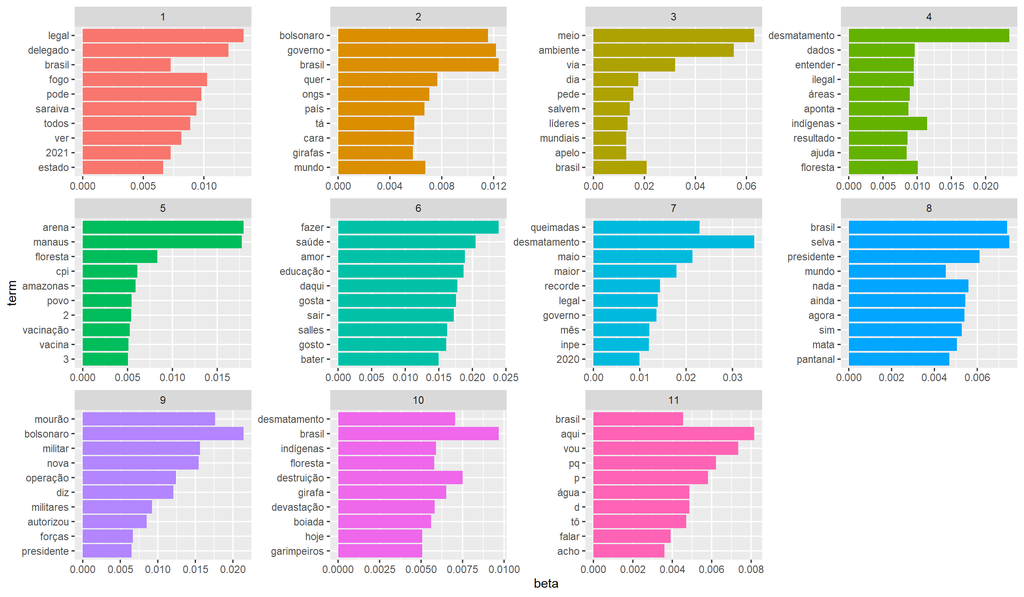

```r
tt_dtm <- tt |> dplyr::count(user_id, word) |>
  dplyr::filter(!stringr::str_detect(word, "amaz[ôóo]nia"),
                !word == "gt") |>
  tidytext::cast_dtm(user_id, word, n)

tt_model <- topicmodels::LDA(tt_dtm, k = 11,
                             control = list(seed = 123))

model_topics <- tidytext::tidy(tt_model, matrix = "beta")

model_top_terms <- model_topics |> dplyr::group_by(topic) |>
  dplyr::top_n(10, beta) |> dplyr::ungroup() |>
  dplyr::arrange(topic, -beta)

model_top_terms |> dplyr::mutate(term = reorder(term, beta)) |>
  ggplot2::ggplot(ggplot2::aes(term, beta, fill = factor(topic))) +
  ggplot2::geom_col(show.legend = FALSE) +
  ggplot2::facet_wrap(~ topic, scales = "free") +
  ggplot2::coord_flip()
```

### structural topic modeling

LDA não é a única forma de topic modeling, apesar de ser a mais comum. uma alternativa é a structural topic modeling (STM), que, além de olhar para as palavras, considera metadados aos quais elas estão associadas – consequentemente, a relação entre esssas variáveis e os tópicos em si.

ainda quero testar com tweets (é possível? quais seriam outras covariáveis? autores? a interação entre os autores? como operacionalizar isso?), então por enquanto deixo algumas referências para se aprofundar:

- [SICSS - Structural Topic Modeling](https://sicss.io/2020/materials/day3-text-analysis/topic-modeling/rmarkdown/Topic_Modeling.html)
- [Using Structural Topic Modeling to Detect Events and Cluster Twitter Users in the Ukrainian Crisis](https://link.springer.com/chapter/10.1007/978-3-319-21380-4_108)